# Task 2.3 线性回归练习

郝建锋

2017-10-31

## 任务一：数据读入与检查

### 1.1 数据导入

```r
dat0 <- read.csv("D:/Desktop/housing.csv", stringsAsFactors=F)
```

### 1.2 检查数据

```r
summary(dat0)           # 查看数据概况
```

```
##      CATE              bedrooms         halls            AREA
##  Length:16210       Min.   :1.000   Min.   :0.000   Min.   : 30.06
##  Class :character   1st Qu.:2.000   1st Qu.:1.000   1st Qu.: 60.00
##  Mode  :character   Median :2.000   Median :1.000   Median : 78.83
##                     Mean   :2.166   Mean   :1.221   Mean   : 91.75
##                     3rd Qu.:3.000   3rd Qu.:2.000   3rd Qu.:110.52
##                     Max.   :5.000   Max.   :3.000   Max.   :299.00
##     floor               subway           school           price
##  Length:16210       Min.   :0.0000   Min.   :0.0000   Min.   : 1.835
##  Class :character   1st Qu.:1.0000   1st Qu.:0.0000   1st Qu.: 4.281
##  Mode  :character   Median :1.0000   Median :0.0000   Median : 5.747
##                     Mean   :0.8278   Mean   :0.3031   Mean   : 6.115
##                     3rd Qu.:1.0000   3rd Qu.:1.0000   3rd Qu.: 7.610
##                     Max.   :1.0000   Max.   :1.0000   Max.   :14.987
##       LONG            LAT            NAME             DISTRICT
##  Min.   :116.0   Min.   :39.66   Length:16210       Length:16210
##  1st Qu.:116.3   1st Qu.:39.89   Class :character   Class :character
##  Median :116.4   Median :39.92   Mode  :character   Mode  :character
##  Mean   :116.4   Mean   :39.93
##  3rd Qu.:116.4   3rd Qu.:39.96
##  Max.   :117.1   Max.   :40.48
```

数据共包含12个变量，其中因变量是单位面积房价。由于经度、纬度、小区名称和所属街区四个变量与因变量关系不大，本文不予考虑。本文选取的自变量共有7个，其中3个为连续型，4个为离散型。所有变量具体情况如下表所示：

[output not shown]

为了深入分析各因素对二手房房价的影响，本文接下来将建立单位面积房价的回归模型，使用定量化的方式更为精确地刻画各因素的影响作用大小。

## 任务二：简单线性模型

以价格(price)为因变量，房屋面积(AREA)和城区(CATE)为自变量，建立简单线性回归模型如下：

```r
lm_a <- lm(price ~ AREA + CATE, data = dat0)
summary(lm_a)           # 展示回归结果
```

```
##
## Call:
## lm(formula = price ~ AREA + CATE, data = dat0)
##
## Residuals:
##     Min      1Q  Median      3Q     Max
## -6.4567 -0.9515 -0.1164  0.8856  7.6624
##
## Coefficients:
##              Estimate Std. Error t value Pr(>|t|)
## (Intercept)  5.463403   0.041358 132.099  < 2e-16 ***
## AREA        -0.001725   0.000280  -6.163  7.3e-10 ***
## CATE东城     1.880476   0.041177  45.668  < 2e-16 ***
## CATE丰台    -1.052211   0.040508 -25.975  < 2e-16 ***
## CATE海淀     1.576293   0.040565  38.858  < 2e-16 ***
## CATE石景山  -1.296275   0.045750 -28.334  < 2e-16 ***
## CATE西城     3.244184   0.041648  77.895  < 2e-16 ***
## ---
## Signif. codes:  0 '***' 0.001 '**' 0.01 '*' 0.05 '.' 0.1 ' ' 1
##
## Residual standard error: 1.538 on 16203 degrees of freedom
## Multiple R-squared:  0.5244, Adjusted R-squared:  0.5242
## F-statistic:  2978 on 6 and 16203 DF,  p-value: < 2.2e-16
```

从输出结果可以看出，**模型整体**调整的$R^2$=0.52（p-值<0.0001），不是很高，说明有很多的因素还没被当前所选的解释变量覆盖，模型还能进一步优化。  
所有的**解释变量**都高度显著（p-值<0.0001），正负号代表着这个变量对价格的影响是正向还是反向，当控制其他因素不变时：

- 房屋面积的增加会带来单位面积房价的降低；
- 对于城区这一变量，单位面积房价由高到低依次为西城、东城、海淀、丰台、石景山，其中西城比石景山每平米平均高出4.54万元。

## 任务三：复杂线性模型

### 3.1 数据处理

将客厅数(halls)变量重新整理成一个新变量style，记录是否有厅：

```r
# 创建新变量style记录是否有厅
dat1 <- dat0
dat1$style <- c("有厅")
dat1$style[which(dat1$halls==0)] <- c("无厅")
# 查看新变量的频数分布情况
table(dat1$style)
```

```
##
##  无厅  有厅
##   812 15398
```

### 3.2 建立模型

现在，运行一个更加复杂的回归模型，命名为lm_b：

```r
lm_b <- lm(price ~ CATE + school + subway + style +
             floor + bedrooms + AREA, data = dat1)
summary(lm_b)
```

```
##
## Call:
## lm(formula = price ~ CATE + school + subway + style + floor +
##     bedrooms + AREA, data = dat1)
##
## Residuals:
##     Min      1Q  Median      3Q     Max
## -5.6695 -0.8872 -0.1489  0.7983  8.0933
##
## Coefficients:
##              Estimate Std. Error t value Pr(>|t|)
## (Intercept)  4.190659   0.070500  59.442  < 2e-16 ***
## CATE东城     1.567919   0.038929  40.276  < 2e-16 ***
## CATE丰台    -0.743800   0.038178 -19.482  < 2e-16 ***
## CATE海淀     1.316134   0.038621  34.079  < 2e-16 ***
## CATE石景山  -0.875123   0.043665 -20.042  < 2e-16 ***
## CATE西城     2.830479   0.039980  70.797  < 2e-16 ***
## school       1.183122   0.027768  42.607  < 2e-16 ***
## subway       0.672102   0.030914  21.741  < 2e-16 ***
## style有厅    0.171935   0.052748   3.260  0.00112 **
## floorlow     0.198526   0.027815   7.137 9.92e-13 ***
## floormiddle  0.152117   0.027142   5.605 2.12e-08 ***
## bedrooms     0.111101   0.020200   5.500 3.86e-08 ***
## AREA        -0.002780   0.000376  -7.393 1.51e-13 ***
## ---
## Signif. codes:  0 '***' 0.001 '**' 0.01 '*' 0.05 '.' 0.1 ' ' 1
##
## Residual standard error: 1.427 on 16197 degrees of freedom
## Multiple R-squared:  0.5904, Adjusted R-squared:  0.5901
## F-statistic:  1945 on 12 and 16197 DF,  p-value: < 2.2e-16
```

新的回归模型调整的$R^2$=0.59（p-值<0.0001），明显优于上面建立的简单线性模型，模型的拟合程度尚可接受。但任务并没有完成，接下来还需要通过模型诊断来判断上述模型还存在某些问题。

## 任务四：复杂模型的诊断

对回归模型lm_b做诊断:

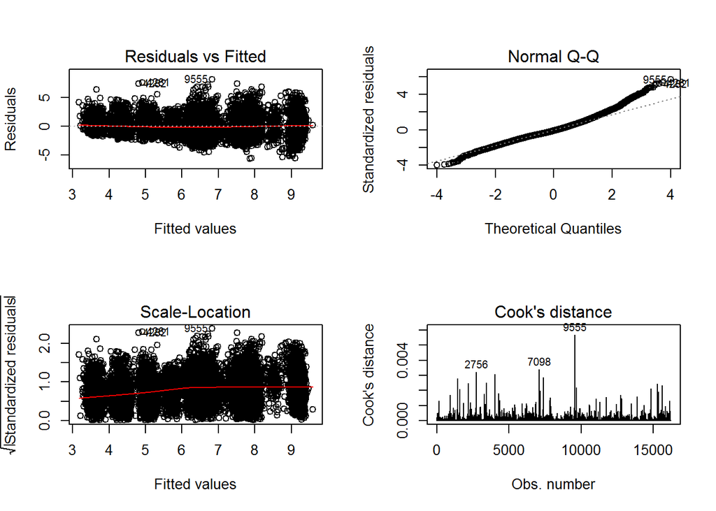

```r
par(mfrow = c(2, 2))
plot(lm_b,which=c(1:4))   # 绘制相关图形进行诊断
```

右下角图中的Cook距离表现正常，表明没有异常点。  
从左上图可以看出，随着预测值的增大，残差的波动也随之增大，右上角的Q-Q图也产生了偏移，这说明模型可能存在异方差问题。为了解决这一问题，目前公认较好的方法是对因变量单位面积房价做对数处理。

接下来需要看一下自变量的方差膨胀因子：

```r
library(car)              # 需要用car包中vif函数
vif(lm_b)                 # 计算方差膨胀因子
```

```
##              GVIF Df GVIF^(1/(2*Df))
## CATE     1.439432  5        1.037096
## school   1.295933  1        1.138390
## subway   1.083795  1        1.041055
## style    1.053444  1        1.026374
## floor    1.010079  2        1.002510
## bedrooms 2.129557  1        1.459300
## AREA     2.177859  1        1.475757
```

发现所有变量的方差膨胀因子都没有超过10，可以认为自变量之间多重共线性不高。

## 任务五：对数线性模型

在模型lm_b的基础上，以对数房价为因变量，建立对数线性回归模型，命名为lm_c：

```r
lm_c <- lm(log(price) ~ CATE + school + subway + style +
             floor + bedrooms + AREA, data = dat1)
summary(lm_c)
```

```
##
## Call:
## lm(formula = log(price) ~ CATE + school + subway + style + floor +
##     bedrooms + AREA, data = dat1)
##
## Residuals:
##     Min      1Q  Median      3Q     Max
## -1.2344 -0.1448 -0.0031  0.1497  1.0087
##
## Coefficients:
##               Estimate Std. Error t value Pr(>|t|)
## (Intercept)  1.442e+00  1.126e-02 128.068  < 2e-16 ***
## CATE东城     2.521e-01  6.216e-03  40.551  < 2e-16 ***
## CATE丰台    -1.615e-01  6.096e-03 -26.498  < 2e-16 ***
## CATE海淀     2.263e-01  6.166e-03  36.703  < 2e-16 ***
## CATE石景山  -2.057e-01  6.972e-03 -29.497  < 2e-16 ***
## CATE西城     4.213e-01  6.384e-03  66.002  < 2e-16 ***
## school       1.719e-01  4.434e-03  38.772  < 2e-16 ***
## subway       1.282e-01  4.936e-03  25.963  < 2e-16 ***
## style有厅    2.750e-02  8.422e-03   3.266  0.00109 **
## floorlow     3.389e-02  4.441e-03   7.630 2.48e-14 ***
## floormiddle  2.597e-02  4.334e-03   5.993 2.10e-09 ***
## bedrooms     1.406e-02  3.225e-03   4.358 1.32e-05 ***
## AREA        -3.507e-04  6.004e-05  -5.842 5.27e-09 ***
## ---
## Signif. codes:  0 '***' 0.001 '**' 0.01 '*' 0.05 '.' 0.1 ' ' 1
##
## Residual standard error: 0.2279 on 16197 degrees of freedom
## Multiple R-squared:  0.6082, Adjusted R-squared:  0.6079
## F-statistic:  2095 on 12 and 16197 DF,  p-value: < 2.2e-16
```

可以看到，模型仍然是显著的（p-值<0.0001），调整的$R^2$=0.6079，模型的拟合程度略有上升。  
需要注意的是，与线性模型不同，对数线性模型的系数估计值应解读为“增长率”，即某自变量变动一个单位，因变量变化的百分比。因此，从上面输出结果可以得到以下结论：在控制其他因素不变的情况下，

- 不同城区单位面积房价由高到低依次为：西城、东城、海淀、丰台和石景山；
- 学区房比非学区房的单位面积房价平均贵17.19%；
- 地铁房比非地铁房的单位面积房价平均贵12.82%；
- 高层房屋单位面积房价最低，其次为中层，低层房屋单位面积房价最高；
- 有客厅的房子单位面积房价更高，平均贵2.75%；
- 卧室数每增加一间，单位面积房价平均增加1.40%；
- 房屋面积的增加会带来单位面积房价的降低。

## 任务六：对数线性交互模型

在lm_c的基础上，加入城区*学区的交互作用，将这个模型命名为lm_d：

```r
lm_d <- lm(log(price) ~ CATE*school + subway + style +
             floor + bedrooms + AREA, data = dat1)
summary(lm_d)
```

```
##
## Call:
## lm(formula = log(price) ~ CATE * school + subway + style + floor +
##     bedrooms + AREA, data = dat1)
##
## Residuals:
##      Min       1Q   Median       3Q      Max
## -1.22784 -0.14546 -0.00519  0.14964  1.00392
##
## Coefficients:
##                     Estimate Std. Error t value Pr(>|t|)
## (Intercept)        1.459e+00  1.142e-02 127.742  < 2e-16 ***
## CATE东城           2.283e-01  7.580e-03  30.114  < 2e-16 ***
## CATE丰台          -1.754e-01  6.458e-03 -27.162  < 2e-16 ***
## CATE海淀           1.937e-01  7.585e-03  25.543  < 2e-16 ***
## CATE石景山        -2.184e-01  7.248e-03 -30.132  < 2e-16 ***
## CATE西城           3.993e-01  8.168e-03  48.882  < 2e-16 ***
## school             9.796e-02  1.045e-02   9.372  < 2e-16 ***
## subway             1.257e-01  4.934e-03  25.475  < 2e-16 ***
## style有厅          2.709e-02  8.401e-03   3.225  0.00126 **
## floorlow           3.433e-02  4.426e-03   7.757 9.18e-15 ***
## floormiddle        2.638e-02  4.318e-03   6.110 1.02e-09 ***
## bedrooms           1.427e-02  3.216e-03   4.437 9.18e-06 ***
## AREA              -3.525e-04  5.987e-05  -5.888 3.99e-09 ***
## CATE东城:school    9.261e-02  1.357e-02   6.826 9.07e-12 ***
## CATE丰台:school    1.684e-02  2.603e-02   0.647  0.51770
## CATE海淀:school    1.096e-01  1.344e-02   8.160 3.61e-16 ***
## CATE石景山:school -2.780e-01  5.480e-02  -5.073 3.95e-07 ***
## CATE西城:school    8.577e-02  1.362e-02   6.296 3.13e-10 ***
## ---
## Signif. codes:  0 '***' 0.001 '**' 0.01 '*' 0.05 '.' 0.1 ' ' 1
##
## Residual standard error: 0.2271 on 16192 degrees of freedom
## Multiple R-squared:  0.6112, Adjusted R-squared:  0.6108
## F-statistic:  1497 on 17 and 16192 DF,  p-value: < 2.2e-16
```

可以看到，考虑交互效应后，模型仍然是显著的（p-值<0.0001），且模型的拟合效果略有提高（调整后的$R^2$=0.6108）。  
一个明显的变化是：在石景山区，**城区*学区**变量系数为负，所以得出结论，在石景山区，学区房比非学区房的单位面积房价低。推测出现这一结果的原因有二：1、石景山区样本中学区房比例过低；2、石景山区的学区资源相对较差。